# Regresión Lineal Múltiple

Patricia Guerrero

02 de Agosto del 2015

### Introducción

En el presente trabajo vamos a realizar la planteación de un modelo mediante regresión múltiple de los archivos población1 y población2, y para ello seguiremos las instrucciones del **trabajo final** de la materia de **Modelos Lineales**.

**1.** Realice un Fork del repositorio Regresion-Lineal-Multiple.

**2.** Genere un archivo rlm.R, de tal forma que le permita responder las siguientes preguntas:

**2.1** Leer los archivos poblacion1.xlsx y poblacion2.xlsx , y analizar sus dimensiones.

Temos las siguientes datos: Los datos de la población 1, la guardamos como data1:

```r
library(readxl)
data1 <- read_excel("poblacion1.xlsx",sheet = 1,col_names = TRUE,na = "")
str(data1)
```

```
## Classes 'tbl_df', 'tbl' and 'data.frame':    44 obs. of  4 variables:
##  $ identificador : num  1001 1002 1003 1004 1005 ...
##  $ poblacion     : num  18.7 13.8 13.4 11.4 10.5 10.3 10.3 10.3 10.3 9.4 ...
##  $ var.pobl.mayor: num  6.2 7.2 7.1 2.6 2.8 1.4 -0.5 3 -1.9 -1.5 ...
##  $ menores.18    : num  39.7 10.4 20.4 38.7 36.4 29.8 31.8 31.1 15.9 22.4 ...
```

```r
names(data1)
```

```
## [1] "identificador"  "poblacion"      "var.pobl.mayor" "menores.18"
```

```r
summary(data1)
```

```
##  identificador    poblacion      var.pobl.mayor     menores.18
##  Min.   :1001   Min.   : 1.700   Min.   :-3.300   Min.   : 7.50
##  1st Qu.:1012   1st Qu.: 4.175   1st Qu.: 1.975   1st Qu.:20.62
##  Median :1022   Median : 7.250   Median : 4.700   Median :28.85
##  Mean   :1022   Mean   : 7.041   Mean   : 7.832   Mean   :27.27
##  3rd Qu.:1033   3rd Qu.: 9.325   3rd Qu.: 8.200   3rd Qu.:33.55
##  Max.   :1044   Max.   :18.700   Max.   :68.600   Max.   :41.50
```

```r
n1<-dim(data1)
n1
```

```
## [1] 44  4
```

Se obtuvo 4 variables con 44 observaciones.

```r
library(DT)
datatable(data1)
```

|  | identificador | poblacion | var.pobl.mayor | menores.18 |
| --- | --- | --- | --- | --- |
| 1 | 1001 | 18.7 | 6.2 | 39.7 |
| 2 | 1002 | 13.8 | 7.2 | 10.4 |
| 3 | 1003 | 13.4 | 7.1 | 20.4 |
| 4 | 1004 | 11.4 | 2.6 | 38.7 |
| 5 | 1005 | 10.5 | 2.8 | 36.4 |
| 6 | 1006 | 10.3 | 1.4 | 29.8 |
| 7 | 1007 | 10.3 | -0.5 | 31.8 |
| 8 | 1008 | 10.3 | 3 | 31.1 |
| 9 | 1009 | 10.3 | -1.9 | 15.9 |
| 10 | 1010 | 9.4 | -1.5 | 22.4 |

[output cut: 34 more lines]

Los datos de la población 2, la guardamos como data2:

```r
library(readxl)
data2 <- read_excel("poblacion2.xlsx",sheet = 1,col_names = TRUE,na = "")
str(data2)
```

```
## Classes 'tbl_df', 'tbl' and 'data.frame':    40 obs. of  7 variables:
##  $ identificador  : num  1044 1042 1010 1009 1008 ...
##  $ part.almz.escl : num  73.8 34.4 22.2 39.9 51.7 57.2 43.7 72.3 78.2 13.9 ...
##  $ var.ingresos   : num  50.5 24.2 33.5 38.5 26.2 27.2 29.4 26 18.4 22.5 ...
##  $ tasa.crimen    : num  704.1 179.9 61.5 86.4 42.4 ...
##  $ var.tasa.crimen: num  -40.9 12.3 -32.7 -13.5 -31.9 -17.6 -10 -21.6 -12.8 -33.6 ...
##  $ region         : chr  "B" "B" "A" "A" ...
##  $ serv.bas.compl : chr  "SI" "NO" "NO" "SI" ...
```

```r
names(data2)
```

```
## [1] "identificador"   "part.almz.escl"  "var.ingresos"    "tasa.crimen"
## [5] "var.tasa.crimen" "region"          "serv.bas.compl"
```

```r
summary(data2)
```

```
##  identificador  part.almz.escl   var.ingresos    tasa.crimen
##  Min.   :1001   Min.   : 5.70   Min.   :11.70   Min.   : 32.00
##  1st Qu.:1011   1st Qu.:33.25   1st Qu.:23.65   1st Qu.: 62.33
##  Median :1020   Median :57.55   Median :26.35   Median : 81.95
##  Mean   :1022   Mean   :53.17   Mean   :26.79   Mean   :111.03
##  3rd Qu.:1033   3rd Qu.:77.53   3rd Qu.:29.40   3rd Qu.:124.15
##  Max.   :1044   Max.   :88.50   Max.   :50.50   Max.   :704.10
##  var.tasa.crimen      region          serv.bas.compl
##  Min.   :-45.600   Length:40          Length:40
##  1st Qu.:-32.050   Class :character   Class :character
##  Median :-13.700   Mode  :character   Mode  :character
##  Mean   :-15.963
##  3rd Qu.: -7.975
##  Max.   : 27.200
```

```r
n2<-dim(data1)
n2
```

```
## [1] 44  4
```

```r
library(DT)
datatable(data2)
```

|  | identificador | part.almz.escl | var.ingresos | tasa.crimen | var.tasa.crimen | region | serv.bas.compl |
| --- | --- | --- | --- | --- | --- | --- | --- |
| 1 | 1044 | 73.8 | 50.5 | 704.1 | -40.9 | B | SI |
| 2 | 1042 | 34.4 | 24.2 | 179.9 | 12.3 | B | NO |
| 3 | 1010 | 22.2 | 33.5 | 61.5 | -32.7 | A | NO |
| 4 | 1009 | 39.9 | 38.5 | 86.4 | -13.5 | A | SI |
| 5 | 1008 | 51.7 | 26.2 | 42.4 | -31.9 | A | NO |
| 6 | 1007 | 57.2 | 27.2 | 61.2 | -17.6 | A | NO |
| 7 | 1006 | 43.7 | 29.4 | 54 | -10 | A | NO |
| 8 | 1005 | 72.3 | 26 | 77.5 | -21.6 | A | SI |
| 9 | 1004 | 78.2 | 18.4 | 86.6 | -12.8 | A | NO |
| 10 | 1003 | 13.9 | 22.5 | 38.3 | -33.6 | A | NO |

[output cut: 30 more lines]

**2.2** Una los archivos leídos en un mismo objeto llamado poblacion.

Realizamos la unión de las dos bases de datos dadas:

```r
poblacion <- merge(data1, data2, by = "identificador", suffixes = c("",""))
str(poblacion)
```

```
## 'data.frame':    40 obs. of  10 variables:
##  $ identificador  : num  1001 1002 1003 1004 1005 ...
##  $ poblacion      : num  18.7 13.8 13.4 11.4 10.5 10.3 10.3 10.3 10.3 9.4 ...
##  $ var.pobl.mayor : num  6.2 7.2 7.1 2.6 2.8 1.4 -0.5 3 -1.9 -1.5 ...
##  $ menores.18     : num  39.7 10.4 20.4 38.7 36.4 29.8 31.8 31.1 15.9 22.4 ...
##  $ part.almz.escl : num  55.8 57.9 13.9 78.2 72.3 43.7 57.2 51.7 39.9 22.2 ...
##  $ var.ingresos   : num  28.7 26.2 22.5 18.4 26 29.4 27.2 26.2 38.5 33.5 ...
##  $ tasa.crimen    : num  52.6 111 38.3 86.6 77.5 54 61.2 42.4 86.4 61.5 ...
##  $ var.tasa.crimen: num  -2.9 -22.6 -33.6 -12.8 -21.6 -10 -17.6 -31.9 -13.5 -32.7 ...
##  $ region         : chr  "A" "A" "A" "A" ...
##  $ serv.bas.compl : chr  "SI" "SI" "NO" "NO" ...
```

```r
names(poblacion)
```

```
##  [1] "identificador"   "poblacion"       "var.pobl.mayor"
##  [4] "menores.18"      "part.almz.escl"  "var.ingresos"
##  [7] "tasa.crimen"     "var.tasa.crimen" "region"
## [10] "serv.bas.compl"
```

```r
summary(poblacion)
```

```
##  identificador    poblacion      var.pobl.mayor     menores.18
##  Min.   :1001   Min.   : 1.700   Min.   :-3.300   Min.   : 7.50
##  1st Qu.:1011   1st Qu.: 4.175   1st Qu.: 1.975   1st Qu.:20.38
##  Median :1020   Median : 7.450   Median : 4.700   Median :28.85
##  Mean   :1022   Mean   : 7.232   Mean   : 6.647   Mean   :27.07
##  3rd Qu.:1033   3rd Qu.: 9.400   3rd Qu.: 8.200   3rd Qu.:33.55
##  Max.   :1044   Max.   :18.700   Max.   :32.200   Max.   :41.50
##  part.almz.escl   var.ingresos    tasa.crimen     var.tasa.crimen
##  Min.   : 5.70   Min.   :11.70   Min.   : 32.00   Min.   :-45.600
##  1st Qu.:33.25   1st Qu.:23.65   1st Qu.: 62.33   1st Qu.:-32.050
##  Median :57.55   Median :26.35   Median : 81.95   Median :-13.700
##  Mean   :53.17   Mean   :26.79   Mean   :111.03   Mean   :-15.963
##  3rd Qu.:77.53   3rd Qu.:29.40   3rd Qu.:124.15   3rd Qu.: -7.975
##  Max.   :88.50   Max.   :50.50   Max.   :704.10   Max.   : 27.200
##     region          serv.bas.compl
##  Length:40          Length:40
##  Class :character   Class :character
##  Mode  :character   Mode  :character
##
##
##
```

Se obtuvo 10 variables con 40 observaciones.

```r
library(DT)
datatable(poblacion)
```

|  | identificador | poblacion | var.pobl.mayor | menores.18 | part.almz.escl | var.ingresos | tasa.crimen | var.tasa.crimen | region | serv.bas.compl |
| --- | --- | --- | --- | --- | --- | --- | --- | --- | --- | --- |
| 1 | 1001 | 18.7 | 6.2 | 39.7 | 55.8 | 28.7 | 52.6 | -2.9 | A | SI |
| 2 | 1002 | 13.8 | 7.2 | 10.4 | 57.9 | 26.2 | 111 | -22.6 | A | SI |
| 3 | 1003 | 13.4 | 7.1 | 20.4 | 13.9 | 22.5 | 38.3 | -33.6 | A | NO |
| 4 | 1004 | 11.4 | 2.6 | 38.7 | 78.2 | 18.4 | 86.6 | -12.8 | A | NO |
| 5 | 1005 | 10.5 | 2.8 | 36.4 | 72.3 | 26 | 77.5 | -21.6 | A | SI |
| 6 | 1006 | 10.3 | 1.4 | 29.8 | 43.7 | 29.4 | 54 | -10 | A | NO |
| 7 | 1007 | 10.3 | -0.5 | 31.8 | 57.2 | 27.2 | 61.2 | -17.6 | A | NO |
| 8 | 1008 | 10.3 | 3 | 31.1 | 51.7 | 26.2 | 42.4 | -31.9 | A | NO |
| 9 | 1009 | 10.3 | -1.9 | 15.9 | 39.9 | 38.5 | 86.4 | -13.5 | A | SI |
| 10 | 1010 | 9.4 | -1.5 | 22.4 | 22.2 | 33.5 | 61.5 | -32.7 | A | NO |

[output cut: 30 more lines]

**2.3** Cree un código que identifique la clase de cada variable y genere diagramas de cajas para variables continuas y diagramas de barras para variables discretas.

```
##  [1] "double"    "double"    "double"    "double"    "double"
##  [6] "double"    "double"    "double"    "character" "character"
```

```
##  [1] "numeric"   "numeric"   "numeric"   "numeric"   "numeric"
##  [6] "numeric"   "numeric"   "numeric"   "character" "character"
```

```
## [1] "poblacion"
```

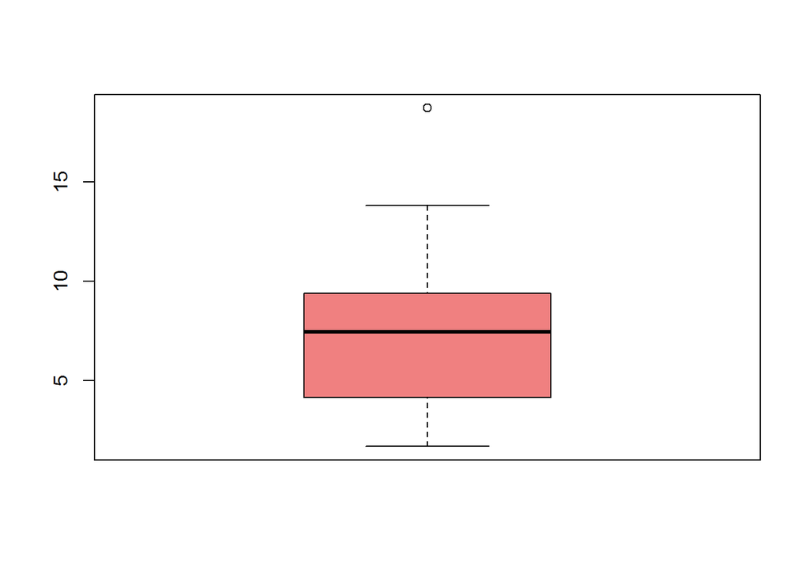

```
## [1] "var.pobl.mayor"
```

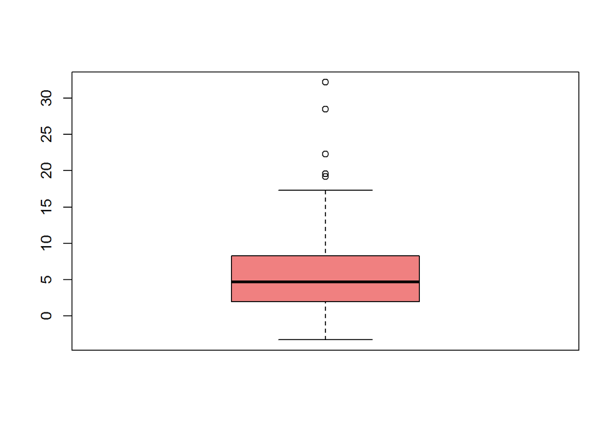

```
## [1] "menores.18"
```

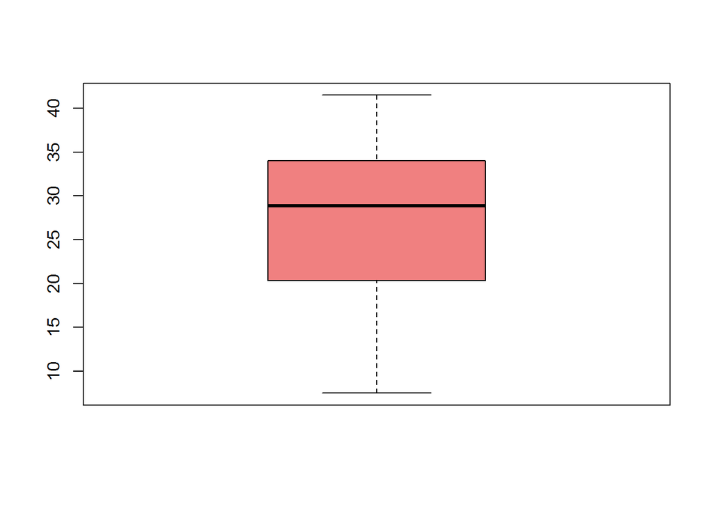

```
## [1] "part.almz.escl"
```

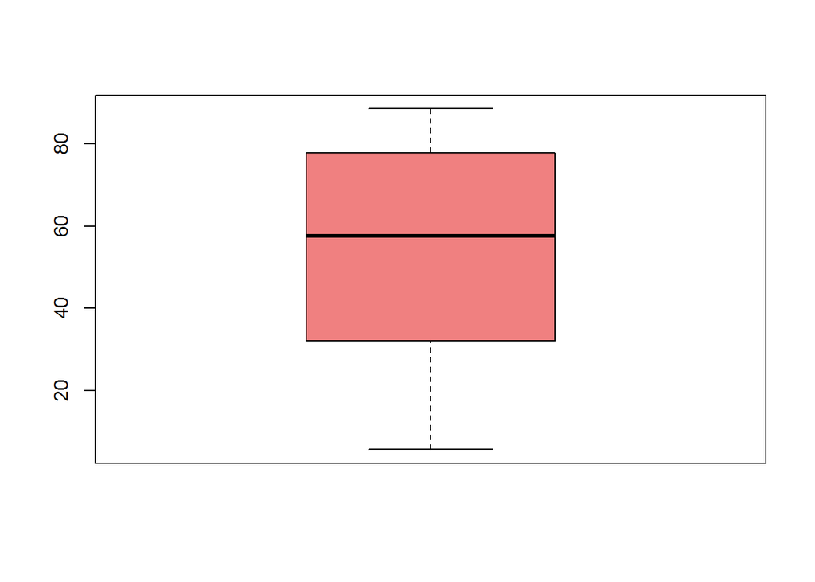

```
## [1] "var.ingresos"
```

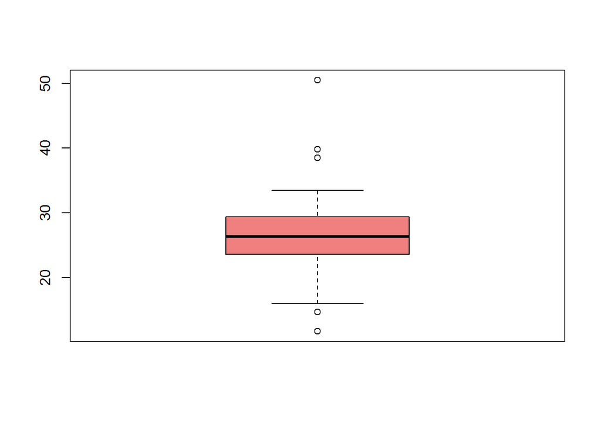

```
## [1] "tasa.crimen"
```

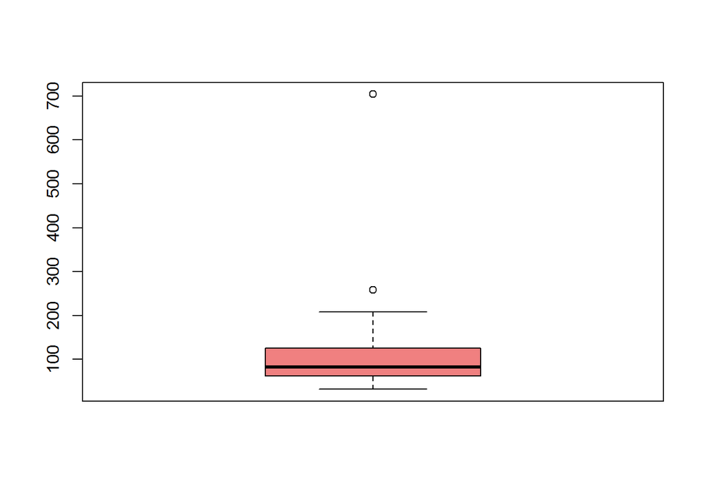

```
## [1] "var.tasa.crimen"
```

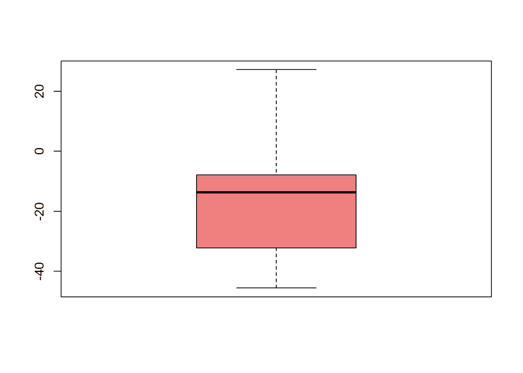

```
## [1] "region"
```

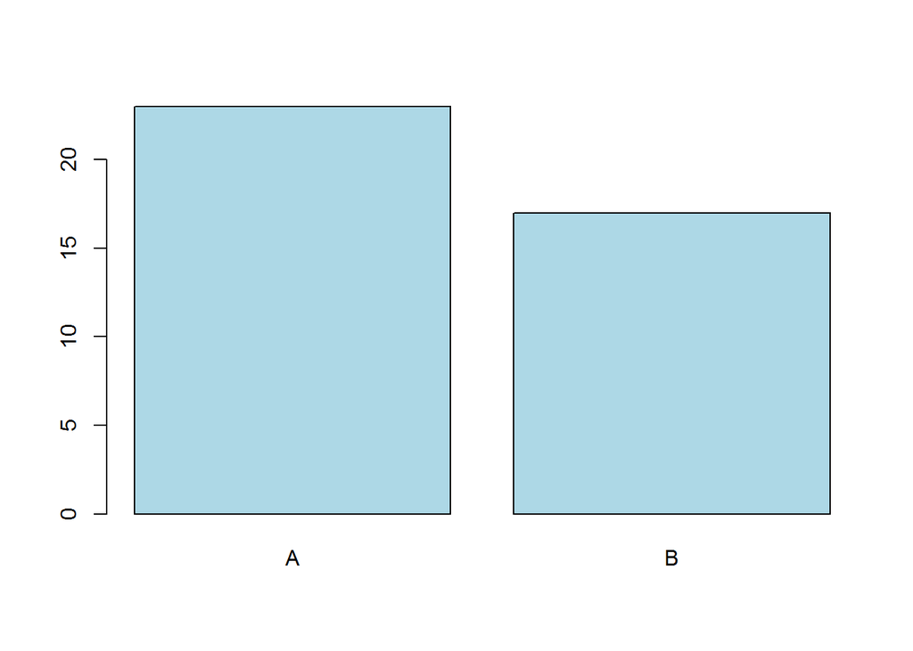

```
## [1] "serv.bas.compl"
```

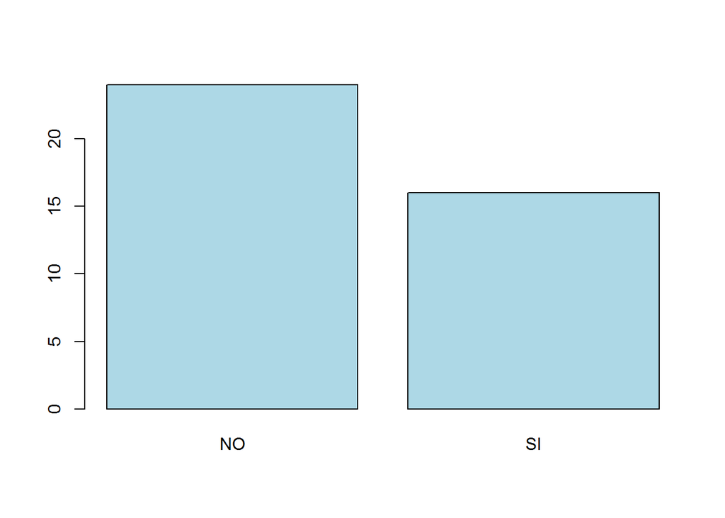

**2.4** Cree un código que calcule automáticamente el mínimo, media, máximo, desviación estándar, primer cuartil de cada variable numérica y la frecuencia en el caso de variables categóricas.

```r
for(j in 2:dim(poblacion)[2]){
  if(is.numeric(poblacion[,j])==TRUE){

    print(names(poblacion)[j])
    print(class(poblacion[,j]))

    print(max(poblacion[,j]))
    print(min(poblacion[,j]))
    print(mean(poblacion[,j]))
    print(sd(poblacion[,j]))
    print(quantile(poblacion[,j],probs=seq(0,1,0.25),na.rm = FALSE))
  }else {

    print(names(poblacion)[j])
    print(class(poblacion[,j]))
    print(table(poblacion[,j])/dim(poblacion)[1])
  }

}
```

```
## [1] "poblacion"
## [1] "numeric"
## [1] 18.7
## [1] 1.7
## [1] 7.2325
## [1] 3.621403
##     0%    25%    50%    75%   100%
##  1.700  4.175  7.450  9.400 18.700
## [1] "var.pobl.mayor"
## [1] "numeric"
## [1] 32.2
## [1] -3.3
## [1] 6.6475
## [1] 8.148776
##     0%    25%    50%    75%   100%
## -3.300  1.975  4.700  8.200 32.200
## [1] "menores.18"
## [1] "numeric"
## [1] 41.5
## [1] 7.5
## [1] 27.0725
## [1] 9.036337
##     0%    25%    50%    75%   100%
##  7.500 20.375 28.850 33.550 41.500
## [1] "part.almz.escl"
## [1] "numeric"
## [1] 88.5
## [1] 5.7
## [1] 53.175
## [1] 25.42078
##     0%    25%    50%    75%   100%
##  5.700 33.250 57.550 77.525 88.500
## [1] "var.ingresos"
## [1] "numeric"
## [1] 50.5
## [1] 11.7
## [1] 26.7875
## [1] 6.854165
##    0%   25%   50%   75%  100%
## 11.70 23.65 26.35 29.40 50.50
```

[output cut: 11 more lines]

```
## [1] -45.6
## [1] -15.9625
## [1] 15.75862
##      0%     25%     50%     75%    100%
## -45.600 -32.050 -13.700  -7.975  27.200
## [1] "region"
## [1] "character"
##
##     A     B
## 0.575 0.425
## [1] "serv.bas.compl"
## [1] "character"
##
##  NO  SI
## 0.6 0.4
```

**2.5** Calcule la correlación entre la variable dependiente poblacion y cada una de las variables explicativas (numéricas).

```r
for(i in 3:dim(poblacion)[2]){
  if(is.numeric(poblacion[,i])==TRUE){
    correlacion<-cor(poblacion[,2],poblacion[,i])
     print(names(poblacion)[i])
    print(correlacion)

  }
}
```

```
## [1] "var.pobl.mayor"
## [1] -0.1577403
## [1] "menores.18"
## [1] 0.1970906
## [1] "part.almz.escl"
## [1] -0.04686172
## [1] "var.ingresos"
## [1] -0.07677708
## [1] "tasa.crimen"
## [1] -0.3749225
## [1] "var.tasa.crimen"
## [1] -0.07645301
```

La correlación de $var.pobl.mayor$:

$cor(poblacion,var.pobl.mayor)=-0.1577403$

La correlación de $menores.18$:

$cor(poblacion,menores.18)=0.1970906$

La correlación de $part.almz.escl$:

$cor(poblacion,part.almz.escl)=-0.04686172$

La correlación de $var.ingresos$:

$cor(poblacion,var.ingresos)=-0.07677708$

La correlación de $tasa.crimen$:

$cor(poblacion,tasa.crimen)=-0.3749225$

La correlación de $var.tasa.crimen$:

$cor(poblacion,var.tasa.crimen)=-0.07645301$

**2.6** Considere la variable categórica serv.bas.compl con una confiabilidad del 90%, ¿ Puede asumirse que la media de la variable poblacion en el grupo serv.bas.compl: SI es distinta a la media del grupo serv.bas.compl: NO?. Utilice la función:t.test

Primero vamos a modificar la data, para transformar a “factor las columnas region y serv.bas…” para poder usar el test t(student).

```r
servicios<-factor(poblacion[,"serv.bas.compl"],levels=c("SI","NO"),labels=c("si","no"))
region<-factor(poblacion[,"region"],levels=c("A","B"),labels=c("a","b"))
poblacion_fac<-data.frame(poblacion[,1:7],region,servicios)
```

Luego hacemos un grafico de cajas para observar como se comporta la “poblacion” en los dos grupos

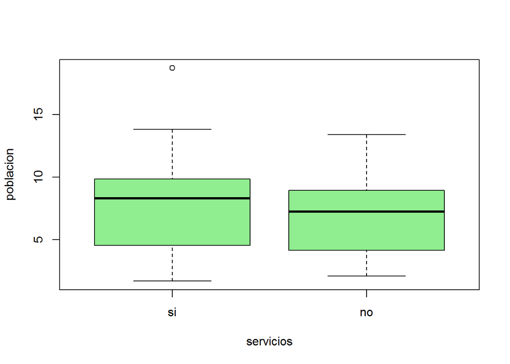

Finalmente realizamos la prueba de hipotesis para la diferencia de medias

```r
t.test(poblacion ~ servicios , data = poblacion_fac, conf.level=0.9)
```

```
##
##  Welch Two Sample t-test
##
## data:  poblacion by servicios
## t = 0.91985, df = 24.672, p-value = 0.3666
## alternative hypothesis: true difference in means is not equal to 0
## 90 percent confidence interval:
##  -0.9901808  3.2985141
## sample estimates:
## mean in group si mean in group no
##         7.925000         6.770833
```

**2.7** Considerando los cálculos anteriores genere el modelo de regresión lineal múltiple que mejor se ajuste a los datos. Interprete los coeficientes obtenidos.

```r
regresion<-lm(poblacion~var.pobl.mayor+menores.18+tasa.crimen,data=poblacion)
summary(regresion)
```

```
##
## Call:
## lm(formula = poblacion ~ var.pobl.mayor + menores.18 + tasa.crimen,
##     data = poblacion)
##
## Residuals:
##     Min      1Q  Median      3Q     Max
## -5.0239 -2.6986 -0.3656  2.0947 10.2333
##
## Coefficients:
##                 Estimate Std. Error t value Pr(>|t|)
## (Intercept)     7.388436   2.048573   3.607 0.000933 ***
## var.pobl.mayor  0.029694   0.082263   0.361 0.720238
## menores.18      0.039498   0.064026   0.617 0.541179
## tasa.crimen    -0.012813   0.006367  -2.012 0.051730 .
## ---
## Signif. codes:  0 '***' 0.001 '**' 0.01 '*' 0.05 '.' 0.1 ' ' 1
##
## Residual standard error: 3.468 on 36 degrees of freedom
## Multiple R-squared:  0.1533, Adjusted R-squared:  0.08277
## F-statistic: 2.173 on 3 and 36 DF,  p-value: 0.1081
```

EL modelo obtenido es el siguiente:

$\hat{poblacion} = 7.3884361 + 0.0296939\hat{var.pobl.mayor} + 0.0394981\hat{menores.18} -0.0128125 \hat{tasa.crimen}$

Interpretemos los coeficientes del modelo:

- Si las variables: $\hat{var.pobl.mayor}$, $\hat{menores.18}$ se mantienen constantes y la $\hat{tasa.crimen}$ aumenta en una unidad (1%), se tiene que:

la $\hat{poblacion}$ disminuye en promedio -0.0128125 unidades (-0.0128125 %).

- Si las variables: $\hat{var.pobl.mayor}$, $\hat{tasa.crimen}$ se mantienen constantes y la $\hat{menores.18}$ aumenta en una unidad (1%), se tiene que:

la $\hat{poblacion}$ aumenta en promedio 0.0394981 unidades (0.0394981 %).

- Si las variables: $\hat{menores.18}$, $\hat{tasa.crimen}$ se mantienen constantes y la $\hat{var.pobl.mayor}$ aumenta en una unidad (1%), se tiene que:

la $\hat{poblacion}$ aumenta en promedio 0.0296939 unidades (0.0296939 %).

Nota: Se interpreta en términos de porcentajes debido a que las variables están expresadas como porcentajes de variación.

**2.8** Interprete el $R^2$.

```r
summary(regresion)["r.squared"]
```

```
## $r.squared
## [1] 0.1533239
```

El modelo explica el 15.3323897111369 %, de la variabilidad de la Población.

**2.9** Analice la significancia de la regresión y de cada uno de los parámetros individuales.

```r
anova<-aov(regresion)
summary(anova)
```

```
##                Df Sum Sq Mean Sq F value Pr(>F)
## var.pobl.mayor  1   12.7   12.73   1.058 0.3105
## menores.18      1   17.0   16.99   1.412 0.2424
## tasa.crimen     1   48.7   48.70   4.049 0.0517 .
## Residuals      36  433.0   12.03
## ---
## Signif. codes:  0 '***' 0.001 '**' 0.01 '*' 0.05 '.' 0.1 ' ' 1
```

Como $F=1.0579632$ es menor que $F_{1,36}(\frac{\alpha}{2})= 4.1131653$ no rechazo $H_0: \beta_2=0$.

Como $F=1.4123987$ es menor que $F_{1,36}(\frac{\alpha}{2})= 4.1131653$ no rechazo $H_0: \beta_3=0$.

Como $F=4.0488493$ es menor que $F_{1,36}(\frac{\alpha}{2})= 4.1131653$ no rechazo $H_0: \beta_4=0$.

**2.10** Realice un análisis detallado de los residuos.

Empezamos almacenando los residuos en un vector, llamado residuos:

Procedemos a graficar la variable población vs los residuos:

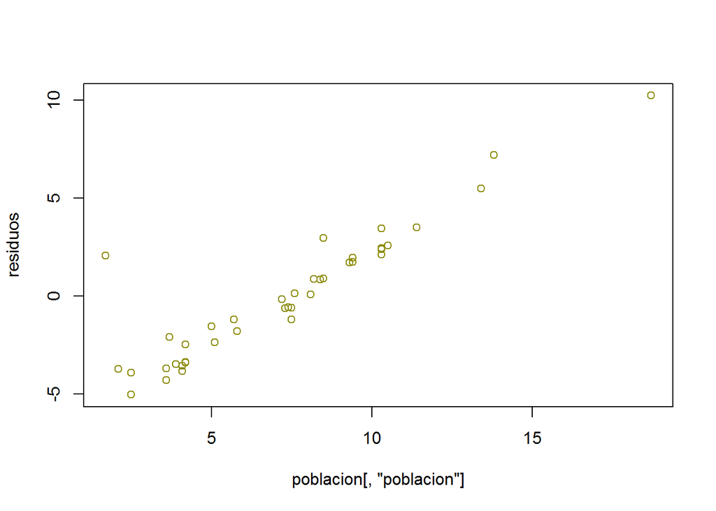

Realizamos un histograma de los residuos:

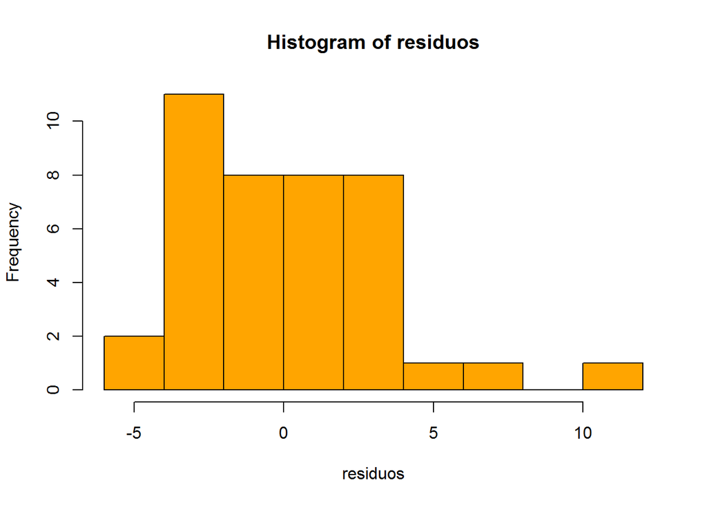

Finalmente realizamos el gráfico de la distribución normal y agregamos la linea de tendencia:

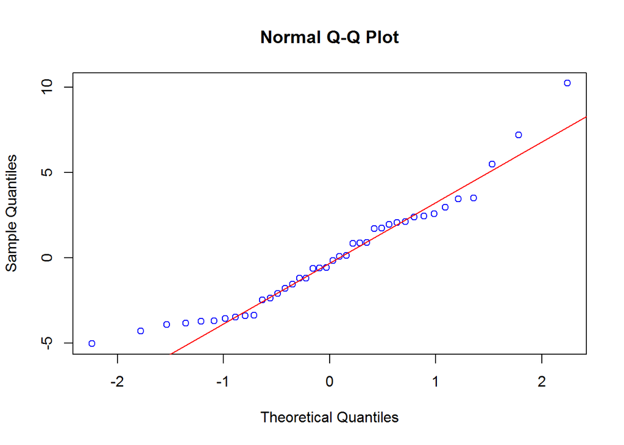

El gráfico de probabilidad normal no rechaza la normalidad de los errores.

**3.** Genere un informe dinámico (archivo rlm.Rmd) en el cual se detalle cada uno de los pasos ejecutados en la generación del modelo de regresión lineal múltiple, las conclusiones y resultados obtenidos.

- Se obtuvo una data general (al unir las dos datas dadas), con 10 variables y 40 observaciones.
- No existe una alta correlación entre la población y las demás variables(var.pobl.mayor, menores.18, part.almz.escl, var.ingresos, tasa.crimen, var.tasa.crimen).
- El modelo que mejor se ajusta es:

$\hat{poblacion} = 7.3884361 + 0.0296939\hat{var.pobl.mayor} + 0.0394981\hat{menores.18} -0.0128125 \hat{tasa.crimen}$

explicando el 15.3323897111369 % de la variabilidad de los datos de la población.

- Un dato que cabe notar es que el crimen y la población son inversamente proporcionales.
- Si las variables: $\hat{var.pobl.mayor}$, $\hat{menores.18}$ se mantienen constantes y la $\hat{tasa.crimen}$ aumenta en una unidad (1%), se tiene que:

la $\hat{poblacion}$ disminuye en promedio -0.0128125 unidades (-0.0128125 %).

- Si las variables: $\hat{var.pobl.mayor}$, $\hat{tasa.crimen}$ se mantienen constantes y la $\hat{menores.18}$ aumenta en una unidad (1%), se tiene que:

la $\hat{poblacion}$ aumenta en promedio 0.0394981 unidades (0.0394981 %).

- Si las variables: $\hat{menores.18}$, $\hat{tasa.crimen}$ se mantienen constantes y la $\hat{var.pobl.mayor}$ aumenta en una unidad (1%), se tiene que:

la $\hat{poblacion}$ aumenta en promedio 0.0296939 unidades (0.0296939 %).

- El gráfico de probabilidad normal no rechaza la normalidad de los errores.